# CS 372/472 & LRN_SCI 372/472

Intro to ABM

Prof. Connor Bain

connor.bain@northwestern.edu

April 7, 2026

## Logistical Stuff

- Homeworks will be due on SUNDAY at 11:59pm instead of Mondays at noon.
  - Can ask for 24 hour extension twice over the quarter. I’ll post a link to a request form on edSTEM later today.
- Please make sure to follow along in the textbook. There are lots more examples in there that might be more interesting to you than the ones we get to in class.
- As we start doing more and more programming, the [Beginners NetLogo Dictionary (BIND)](https://ccl.northwestern.edu/netlogo/bind/) will be more and more useful!
- The most confusing part of NetLogo is how the ‘physical’ (*VIEW*) elements interact with the ‘digital’ (*CODE*) elements.

## Brief History of Agent-based Modeling (Chapter 0)

- Self-organizing / replicating machines (40s to early 60s) – Von Neumann, Ulam
- Game of Life (70s) – Conway
- Cellular Automata (80s) – Wolfram, Hillis, Holland, Toffoli,
- General ABM languages and environments (90s) – Langton, Resnick, Wilensky
- Specialized agent modeling systems (90s/00s) – Axtell/Epstein, Parker, Collier
- More modern ABM toolkits and libraries (10s / 20s)

## Intro to Cellular Automata

### SETUP

- A collection of “cells” arranged either in a [line (1D)](https://mathworld.wolfram.com/ElementaryCellularAutomaton.html) or a grid (2D)
  - Each cell is in a specific state (usually alive or dead)
  - Cells can only “observe” their immediate neighbors

### GO

- Each cell looks at its neighbors: either cardinal (4) or Moore Neighborhood (8)
  - A simple function written in terms of its current state and its neighbors states determines the outcome of that step

## What’s the deal with numerals

- The Roman Empire’s influence was deep, with most of Europe (before the turn of the 1st millenium) using Roman Numerals
- Before widespread adoption of Hindu-Arabic numerals, very few could do multiplication/division
- Scientists recognized superiority immediately
- But widespread adoption took a very long time
- Was in surreptitious use, but not official

## Restructurations (Wilensky & Papert 2006; 2010)

**Note**

A **structuration** the encoding of the knowledge in a domain as a function of the representational infrastructure used to express the knowledge.

**Note**

A **restructuration** is a change from one structuration of a domain to another resulting from a change in representational infrastructure.

**Warning**

**Structural inertia** causes these changes to take *huge* amounts of time.

## Structural Inertia – Deterministic Mindsets

### Wilensky & Resnick

- Tendency to see pattern as orchestrated by a leader: “by lead or by seed”
  - Resistance to distributed explanations or methodology * Tendency to see order as a result of a deterministic procedure
  - Resistance to the role of randomness in creating order
- Levels Confusion
  - Misattributing properties of the individual system elements to properties of the system as a whole

## How does a flock of Geese form?

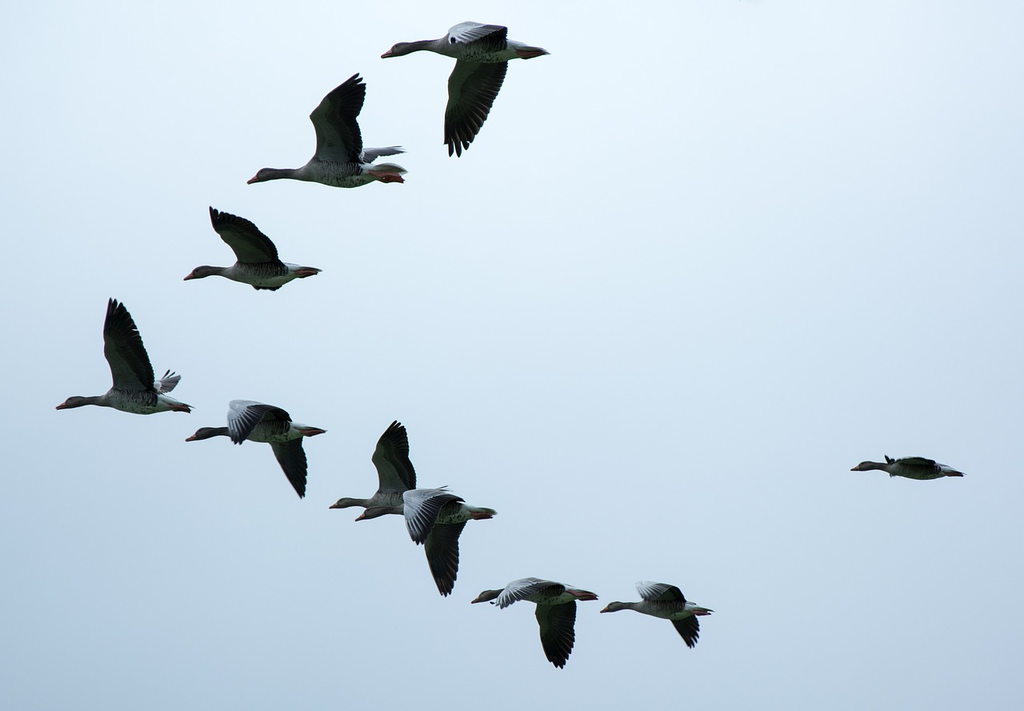

## Real Interviews: How does a flock of Geese form?

- *Minnie*: I think the leader of them is the mother so this is her right here, then behind her and then it always ends up that there is about two or one at the back. I think the smallest one.
- *Alan*: By size, the biggest one in front. Again it could be and so OK they find out that the V formation is more efficient than no formation so then they find that when the birds are arranged this way with the biggest in front and the smallest at the two ends of the V.

## Agent-based Restructurations

- With the invention of computer-based representations such as agent-based modeling, we can create restructurations of complex systems that will allow us to more powerfully understand complex phenomena and make them accessible to the public at large.

$$\begin{aligned}
\frac{dx}{dt} &= \alpha x - \beta xy \\
\frac{dy}{dt} &= \delta xy - \gamma y
\end{aligned}$$

$$\begin{aligned}
\dfrac{dN_1}{dt} = r_1 N_1 \left(1 - \dfrac{N_1 + \alpha_{12} N_2}{K_1}\right) \\[10pt]
\dfrac{dN_2}{dt} = r_2 N_2 \left(1 - \dfrac{N_2 + \alpha_{21} N_1}{K_2}\right)
\end{aligned}$$

## Agent-based Restructuration

### GO (at each clock tick)

- Each `sheep`:
  - I move randomly and lose a little energy
  - If grass on my patch, turn patch brown, increase my energy
  - If `energy < 0` then `die`
- Each `patch`
  - If my `pcolor` is brown, I turn green with probability `GRASS-GROWTH-RATE`.

## Describing Systems that Evolve over Times

- We’ve traditionally have used language of algebra, calculus, differential equations
- Agent modeling has some advantages
  - Easier entry
  - Model individual behavior, not average/population
  - Much easier to extend, modify, experiment
  - Spatial affordances
  - Discrete
  - More easily incorporate stochasticity

## Making assumptions explicit

- By explicating and codifying rules, we can break out of a deterministic-centralized (DC) mindset
- Can test consequences of individual rule-sets
- Can run multiple what-if scenarios
- Arguments get shifted to the character of the underlying rules rather than outcomes (easier to test)

## GROUP ACTIVITY

- Introduce yourselves!
  - Name, Major, Year in School
  - Favorite place to eat in Evanston
- What model did you look at for Exercise 1
  - Why did you pick it?
  - Was it something you already knew about?
  - How does the agent-based explanation differ from your previous (or initial) thoughts about this phenomenon?
- Any surprising / confusing syntactical things about the code?

## Intro to Cellular Automata

### SETUP

- A collection of “cells” arranged either in a [line (1D)](https://mathworld.wolfram.com/ElementaryCellularAutomaton.html) or a grid (2D)
  - Each cell is in a specific state (usually alive or dead)
  - Cells can only “observe” their immediate neighbors

## CA 1D Rule 30

### SETUP

- 1D line of squares where each patch is either **1** (yellow) or **0** (blank).

## Game of Life (Conway & Gardener, 1970s)

### SETUP

- Infinite checkerboard (2D) of patches where each patch is either alive (green) or dead (dark blue)

### GO

- Each cell looks at its Moore neighborhood (8)
  - If I have fewer than two live neighbors, I die.
  - If I have exactly two live neighbors, I stay unchanged.
  - If I have exactly three live neighbors, I become (or stay) alive.
  - If I have more than three live neighbors, I die.

## Emergent Patterns

- **Still Lifes** (e.g., A 4 cell block-shape)
- **Oscillator patterns** repeat over time. (e.g., a blinker)
- **Spaceships**, some Life shapes can move across the Life world. (e.g., Glider)

[video not shown]

## Universe as a Cellular Automata

- Konrad Zuse (1969) – Calculating Space
- Ed Fredkin (1990) – “We hypothesize that there will be found a single CA rule that models all of microscopic physics; and models it exactly.”
- Stephen Wolfram – Classified all 1D CA